# Predicting diabetes from patient’s health information

Sicheng Marc Sun, Heidi Ye  
11/28/2020

- Summary
- Introduction
- Methods
- Data
- Analysis
- Exploratory Data Analysis
- Result & Discussion
  - Decision Tree Hyperparameter Tuning
  - Naive Bayes Hyperparameter Tuning
  - Logistic Regression Hyperparameter Tuning
  - Conclusion
  - Future directions:
- References

# Summary

Here we apply three different classification models, decision tree, Gaussian Naïve Bayes and logistic regression to predict whether a patient has diabetes given features such as age, gender and any other existing conditions. The objective is to find the model that scores the highest f1 score for our target of having diabetes.

Our analysis shows that all three models performed well on an unseen test data set. The logistic regression model has the highest f1 score (defined by : $f1 = \frac{2 \cdot precision \cdot recall}{precision+ recall}$) which is 0.97. The corresponding precision and recall are also 0.97. The two other models also performed well but have slightly lower scores than the logistic regression model. Based on these results, we can conclude that the logistic regression model is the optimal model for this classification problem.

# Introduction

There are currently over 425 million people living with diabetes. With this number on the rise, and many cases going undiagnosed, it is increasingly crucial to be able to predict a diagnosis at an early stage for intervention.

A machine learning model that predicts whether a person has diabetes enables doctors to quickly identify and inform potential candidates that need to begin blood sugar testing. A simplistic and interpretable model can serve as a simple at home self-diagnosing method or help guide doctors on common traits that predict diabetes.

# Methods

This Python programming language (Van Rossum and Drake 2009) and and the following packages were used to perform this analysis: SKLearn (Pedregosa et al. 2011) and Pandas (team 2020). The visualizations were done in the R programming language (R Core Team 2019) with the following packages: Tidyverse (Wickham 2017), Knitr (Xie 2014), Carat(Jed Wing et al. 2019), Reticulate (Ushey, Allaire, and Tang 2020). Docopt (Keleshev 2014) in both R and Python were used.

# Data

The dataset used for the analysis in the project is based on medical screening questions from the patients of Sylhet Diabetes Hospital in Bangladesh collected by M, IslamEmail, Rahatara Ferdousi, Sadikur Rahman and Yasmin Bushra. The dataset was sourced from the UCI Machine Learning Repository and can be found in here specifically this file.

The data used for the project is collected by Sylhet Diabetes Hospital, by using direct questionnaires. The data set was sourced from the UCI Machine Learning Repository (Dua and Graff 2017) and can be found here. Each row of the dataset contains answers to common medical screening questions, and the last column indicates whether the patient has diabetes. This is the response variable and the target we intend to predict on.

# Analysis

The code used to perform the analysis and create this report can be found in the repository [here.](https://github.com/UBC-MDS/DSCI522-2020-g22)

# Exploratory Data Analysis

We begin by splitting our data into 80% training and 20% testing respectively. We perform our exploratory data analysis using just the training portion.

Initially, we can see that we have 16 features and 520 observations. With the exception of age, which is a numeric feature, the remaining are binary and categorical in nature. Since there is no missing data, the main transformations that are required is one hot encoding for the categorical features and scaling for the numeric features.

With 320 observations in the positive class (has diabetes) and 200 observations in the negative class, there doesn’t appear to be any severe class imbalance in the data. Our EDA also indicates that there are no major class imbalance issues on a feature by feature basis. The dataset also does not appear to have any features that seem inappropriate to train with. In general, our dataset came fairly clean and prepared for training without too much additional preprocessing.

# Result & Discussion

We use our 80% split of the training data to train three models: decision tree, Naive Bayes and logistic regression. These models were selected mainly for its simplicity in interpretation. In addition, we were interested in the difference in scoring between a probabilistic and linear model and if one approach would fit the data better than another. The objective is the find the most interpretable model that can accurately predict for diabetes in this dataset.

Initially, the scoring metric used for this analysis was recall, since protecting against false positives is particularly important in predicting disease. However, since many of the features in this dataset are binary, scoring based on recall was consistently overfitting and returning perfect model scores across all models. From these preliminary results, we shifted our scoring method to the f1 score which better balanced recall and precision.

The optimal hyperparameters for each model and their corresponding training and validation scores can be seen in the plots below.

## Decision Tree Hyperparameter Tuning

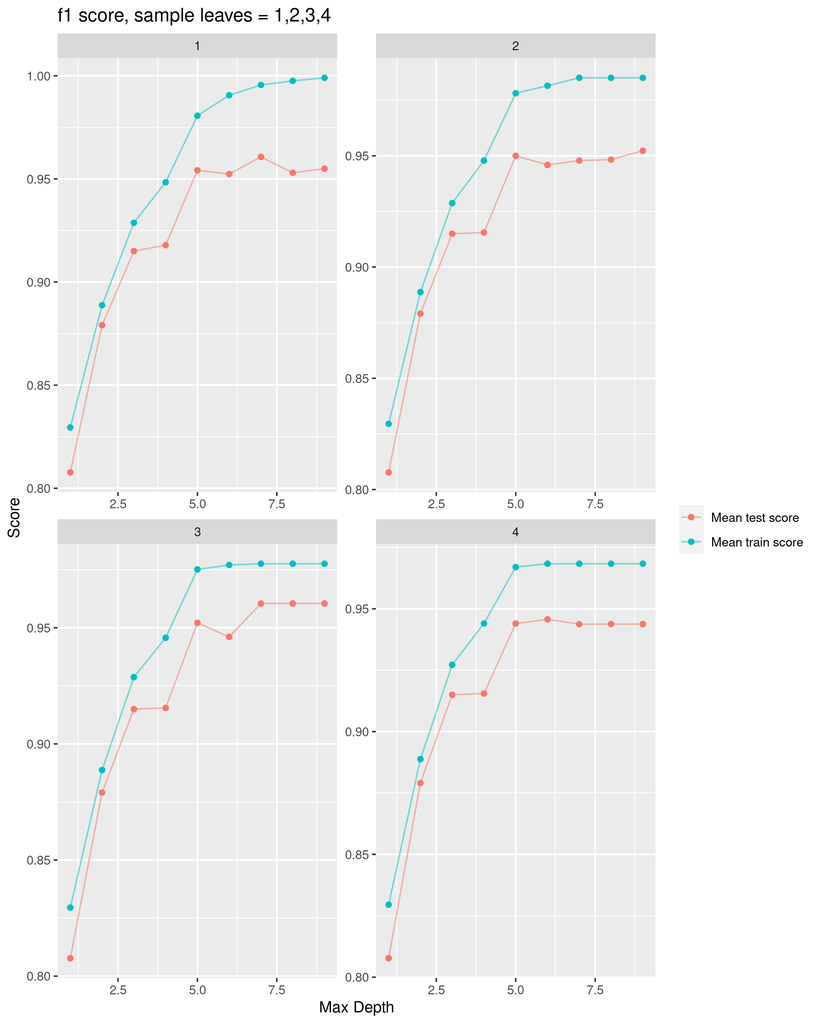

Figure 3: Decision Tree hyperparameter optimization for maximum depth and mimimum leaf values

We can see that the optimal hyperparameter is a maximum depth of the tree is 7 and a minimum of 1 leaves since it returns the highest validation score of 0.96. We can also see that the other three hyperparameter combinations return very similar scores with slightly slower mean fit times.

Our initial hypothesis was that the decision tree model would be one of the most interpretable models with easy to visualize decision splits. However, with the optimal model having a depth of 7, it’s likely a little to complicated for day to day use.

## Naive Bayes Hyperparameter Tuning

Below, we have the figure results of the hyperparameter tuning of variable smoothing of the Naive Bayes model. Again, the blue line indicates the mean train score and the red line indicates the mean validation score.

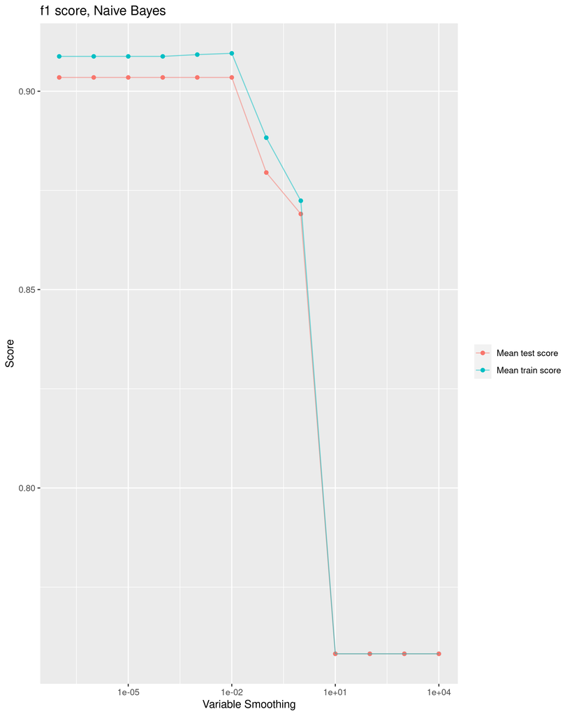

Figure 4: Naive bayes hyperparameter optimization for variable smoothing

The optimal hyperparameter with the Naive Bayes model is when the variable smoothing hyperparameter is set to 10^{-7}. It has a mean validation score of 0.903. Similar to decision trees, the next four highest ranking models (not shown above) seem to perform comparably. This indicates that this model may not too sensitive to the tuning of this hyperparameter.

## Logistic Regression Hyperparameter Tuning

We have the figure results of the hyperparameter tuning of C (controls model complexity) and Solver of the Logistic Regression model below.

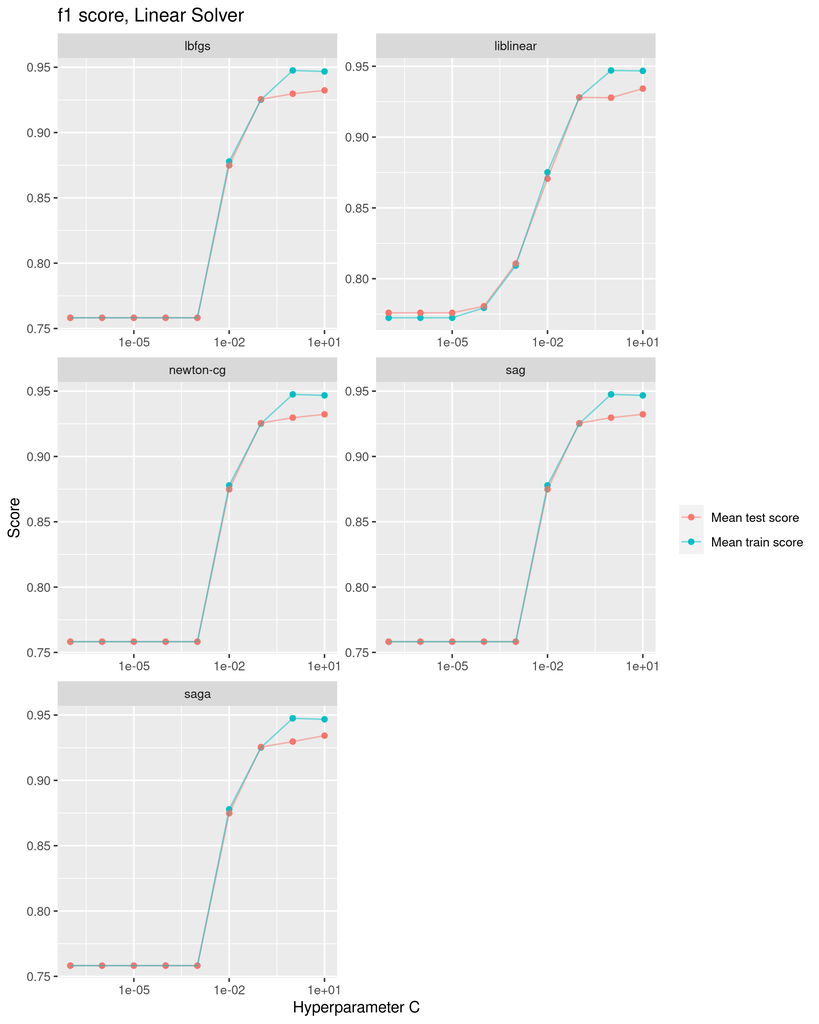

Figure 5: Logisitic regression hyperparameter optimization for variable C and Solver

The optimal hyperparameter is a regularization variable of 10 using the liblinear solver. It has a mean validation score of 0.93. Similar to the two models above, the next four best ranking hyperparameter combinations have a very comparable score but again, our optimal model as the fastest fit time.

## Conclusion

We can summarize each of our hyperparameter tuned models using the f1 score below:

| Model name | F1 score | Recall score | Precision score | Accuracy |
| --- | --- | --- | --- | --- |
| Logistic Regression | 0.9697 | 0.9697 | 0.9697 | 0.9615 |
| Decision Tree | 0.9231 | 0.9091 | 0.9375 | 0.9038 |
| Gaussian NB | 0.9104 | 0.9242 | 0.8971 | 0.8846 |

Table 1

We can see that the logistic regression performs the best with a mean f1 score of approximately 0.97. The two other models perform well with f1 scores of 0.92 and 0.91 for the decision tree and Naive Bayes respectively. In this case, the linear model did fit better than the probabilitic model.

We can conclude that based on the f1 score, the logistic regression is the optimal model out of the three selected models for the predicting a diabetes diagnosis.

## Future directions:

Although the analysis above indicates that the logistic regression is the best model for this dataset, there are a few improvements that can still be made.

- Can we optimize fit and score time through feature selection without compromising on model accuracy?
- Can we make soft predictions instead of hard predictions so that patients have an understanding of their likelihood being diagnosed?
- Can we perform further analysis to understand the error rate in our training model?
- Can we decrease the threshold for predicting positive classes to improve recall scores?

# References

Dua, Dheeru, and Casey Graff. 2017. “UCI Machine Learning Repository.” University of California, Irvine, School of Information; Computer Sciences. http://archive.ics.uci.edu/ml.

M, Rahatara Ferdousi, IslamEmail, and Yasmin Bushra. 2019. “Likelihood prediction of diabetes at early stage using data mining techniques.” In Computer Vision and Machine Intelligence in Medical Image Analysis, edited by Debanjan Konar Mousumi Gupta and Siddhartha Bhattacharyya, 1st ed., 113–25. International Society for Optics; Photonics; Springer.

Jed Wing, Max Kuhn. Contributions from, Steve Weston, Andre Williams, Chris Keefer, Allan Engelhardt, Tony Cooper, Zachary Mayer, et al. 2019. *Caret: Classification and Regression Training*. https://CRAN.R-project.org/package=caret.

Keleshev, Vladimir. 2014. *Docopt* (version 0.6.2).

Pedregosa, F., G. Varoquaux, A. Gramfort, V. Michel, B. Thirion, O. Grisel, M. Blondel, et al. 2011. “Scikit-Learn: Machine Learning in Python.” *Journal of Machine Learning Research* 12: 2825–30.

R Core Team. 2019. *R: A Language and Environment for Statistical Computing*. Vienna, Austria: R Foundation for Statistical Computing. https://www.R-project.org/.

team, The pandas development. 2020. *Pandas-Dev/Pandas: Pandas* (version 1.1.1). Zenodo. https://doi.org/10.5281/zenodo.3993412.

Ushey, Kevin, JJ Allaire, and Yuan Tang. 2020. *Reticulate: Interface to ’Python’*. https://CRAN.R-project.org/package=reticulate.

Van Rossum, Guido, and Fred L. Drake. 2009. *Python 3 Reference Manual*. Scotts Valley, CA: CreateSpace.

Wickham, Hadley. 2017. *Tidyverse: Easily Install and Load the ’Tidyverse’*. https://CRAN.R-project.org/package=tidyverse.

Xie, Yihui. 2014. “Knitr: A Comprehensive Tool for Reproducible Research in R.” In *Implementing Reproducible Computational Research*, edited by Victoria Stodden, Friedrich Leisch, and Roger D. Peng. Chapman; Hall/CRC. http://www.crcpress.com/product/isbn/9781466561595.